# 5_BuildingML_ModelsWithSklearn

## Section 7: Building Machine Learning Models with Scikit-learn

### Compiled by :

```
               Alem H Fitwi,
               PhD Student (Privacy, Deep Learning, Networking (Edge Computing), IoD, Surveillance Systems),
               GA-Data Analyst,
               Binghamton University-State University of New York
```

Will take a look at:

```
Different ML models for solving the problems of regression, classification and clustering.
Linear Regression
Logistic Regression
K-Nearest Neighbors
Decision Trees
Random Forest
K-Means Clustering
```

### 7.1: Linear Regression

Regression algorithms are used when the outcome of interest is a continuous variable.

Linear Regression models the relationship between the dependent and independent variables in a linear way.

The model tries to minimize the total squared error between the predictions and the actual outcomes. This is often done by using the Least Squares Method.

Simple Linear Regression \begin{align} y^{i} & = \beta_{0} + \beta_{1} x^{i} + \epsilon^{i} \\ \end{align}

Multiple Linear Regression \begin{align} y^{i} & = \beta_{0} + \beta_{1} x^{i}_{1} + \beta_{2} x^{i}_{2} + ... + \beta_{k} x^{i}_{k} +\epsilon^{i} \\ \end{align}

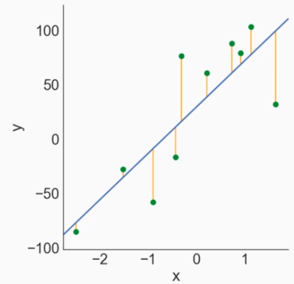

```python
from IPython.display import Image
from IPython.core.display import HTML
Image('ds_7.png')
```

### Import required packages

```python
import pandas as pd
import numpy as np
import seaborn as sns
import sklearn.datasets as data #Scikit-learn can import datasets
```

### Preprocessing the input dataset

```python
wine=data.load_wine()
```

```python
type(wine)
```

```
sklearn.utils.Bunch
```

```python
wine.keys() #gives information about the dataset components
```

```
dict_keys(['data', 'target', 'target_names', 'DESCR', 'feature_names'])
```

```python
# To check the description of each column:
#print(wine.DESCR)
```

```python
wine.data
```

```
array([[1.423e+01, 1.710e+00, 2.430e+00, ..., 1.040e+00, 3.920e+00,
        1.065e+03],
       [1.320e+01, 1.780e+00, 2.140e+00, ..., 1.050e+00, 3.400e+00,
        1.050e+03],
       [1.316e+01, 2.360e+00, 2.670e+00, ..., 1.030e+00, 3.170e+00,
        1.185e+03],
       ...,
       [1.327e+01, 4.280e+00, 2.260e+00, ..., 5.900e-01, 1.560e+00,
        8.350e+02],
       [1.317e+01, 2.590e+00, 2.370e+00, ..., 6.000e-01, 1.620e+00,
        8.400e+02],
       [1.413e+01, 4.100e+00, 2.740e+00, ..., 6.100e-01, 1.600e+00,
        5.600e+02]])
```

```python
wine.feature_names
```

```
['alcohol',
 'malic_acid',
 'ash',
 'alcalinity_of_ash',
 'magnesium',
 'total_phenols',
 'flavanoids',
 'nonflavanoid_phenols',
 'proanthocyanins',
 'color_intensity',
 'hue',
 'od280/od315_of_diluted_wines',
 'proline']
```

```python
# Convert it to dataframes
df=pd.DataFrame(wine.data, columns=wine.feature_names)
```

```python
df.head()
```

|  | alcohol | malic_acid | ash | alcalinity_of_ash | magnesium | total_phenols | flavanoids | nonflavanoid_phenols | proanthocyanins | color_intensity | hue | od280/od315_of_diluted_wines | proline |
| --- | --- | --- | --- | --- | --- | --- | --- | --- | --- | --- | --- | --- | --- |
| 0 | 14.23 | 1.71 | 2.43 | 15.6 | 127.0 | 2.80 | 3.06 | 0.28 | 2.29 | 5.64 | 1.04 | 3.92 | 1065.0 |
| 1 | 13.20 | 1.78 | 2.14 | 11.2 | 100.0 | 2.65 | 2.76 | 0.26 | 1.28 | 4.38 | 1.05 | 3.40 | 1050.0 |
| 2 | 13.16 | 2.36 | 2.67 | 18.6 | 101.0 | 2.80 | 3.24 | 0.30 | 2.81 | 5.68 | 1.03 | 3.17 | 1185.0 |
| 3 | 14.37 | 1.95 | 2.50 | 16.8 | 113.0 | 3.85 | 3.49 | 0.24 | 2.18 | 7.80 | 0.86 | 3.45 | 1480.0 |
| 4 | 13.24 | 2.59 | 2.87 | 21.0 | 118.0 | 2.80 | 2.69 | 0.39 | 1.82 | 4.32 | 1.04 | 2.93 | 735.0 |

```python
df1=df
df1.head()
```

|  | alcohol | malic_acid | ash | alcalinity_of_ash | magnesium | total_phenols | flavanoids | nonflavanoid_phenols | proanthocyanins | color_intensity | hue | od280/od315_of_diluted_wines | proline |
| --- | --- | --- | --- | --- | --- | --- | --- | --- | --- | --- | --- | --- | --- |
| 0 | 14.23 | 1.71 | 2.43 | 15.6 | 127.0 | 2.80 | 3.06 | 0.28 | 2.29 | 5.64 | 1.04 | 3.92 | 1065.0 |
| 1 | 13.20 | 1.78 | 2.14 | 11.2 | 100.0 | 2.65 | 2.76 | 0.26 | 1.28 | 4.38 | 1.05 | 3.40 | 1050.0 |
| 2 | 13.16 | 2.36 | 2.67 | 18.6 | 101.0 | 2.80 | 3.24 | 0.30 | 2.81 | 5.68 | 1.03 | 3.17 | 1185.0 |
| 3 | 14.37 | 1.95 | 2.50 | 16.8 | 113.0 | 3.85 | 3.49 | 0.24 | 2.18 | 7.80 | 0.86 | 3.45 | 1480.0 |
| 4 | 13.24 | 2.59 | 2.87 | 21.0 | 118.0 | 2.80 | 2.69 | 0.39 | 1.82 | 4.32 | 1.04 | 2.93 | 735.0 |

```python
wine.target #categorical type
```

```
array([0, 0, 0, 0, 0, 0, 0, 0, 0, 0, 0, 0, 0, 0, 0, 0, 0, 0, 0, 0, 0, 0,
       0, 0, 0, 0, 0, 0, 0, 0, 0, 0, 0, 0, 0, 0, 0, 0, 0, 0, 0, 0, 0, 0,
       0, 0, 0, 0, 0, 0, 0, 0, 0, 0, 0, 0, 0, 0, 0, 1, 1, 1, 1, 1, 1, 1,
       1, 1, 1, 1, 1, 1, 1, 1, 1, 1, 1, 1, 1, 1, 1, 1, 1, 1, 1, 1, 1, 1,
       1, 1, 1, 1, 1, 1, 1, 1, 1, 1, 1, 1, 1, 1, 1, 1, 1, 1, 1, 1, 1, 1,
       1, 1, 1, 1, 1, 1, 1, 1, 1, 1, 1, 1, 1, 1, 1, 1, 1, 1, 1, 1, 2, 2,
       2, 2, 2, 2, 2, 2, 2, 2, 2, 2, 2, 2, 2, 2, 2, 2, 2, 2, 2, 2, 2, 2,
       2, 2, 2, 2, 2, 2, 2, 2, 2, 2, 2, 2, 2, 2, 2, 2, 2, 2, 2, 2, 2, 2,
       2, 2])
```

```python
# Add target to the DataFrame
df1['wine_type']=wine.target
```

```python
df1.columns
```

```
Index(['alcohol', 'malic_acid', 'ash', 'alcalinity_of_ash', 'magnesium',
       'total_phenols', 'flavanoids', 'nonflavanoid_phenols',
       'proanthocyanins', 'color_intensity', 'hue',
       'od280/od315_of_diluted_wines', 'proline', 'wine_type'],
      dtype='object')
```

```python
# Check the detailed info
# Check if there is missing data
df1.info()
```

```
<class 'pandas.core.frame.DataFrame'>
RangeIndex: 178 entries, 0 to 177
Data columns (total 14 columns):
alcohol                         178 non-null float64
malic_acid                      178 non-null float64
ash                             178 non-null float64
alcalinity_of_ash               178 non-null float64
magnesium                       178 non-null float64
total_phenols                   178 non-null float64
flavanoids                      178 non-null float64
nonflavanoid_phenols            178 non-null float64
proanthocyanins                 178 non-null float64
color_intensity                 178 non-null float64
hue                             178 non-null float64
od280/od315_of_diluted_wines    178 non-null float64
proline                         178 non-null float64
wine_type                       178 non-null int32
dtypes: float64(13), int32(1)
memory usage: 18.9 KB
```

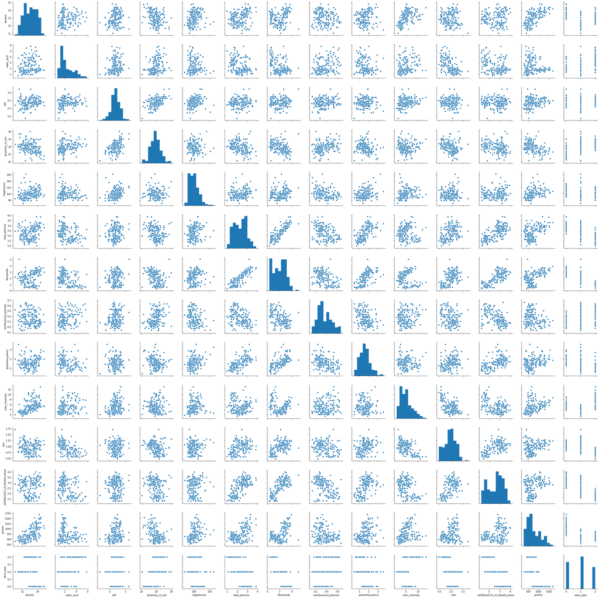

```python
sns.pairplot(df1)
```

From the pairplots above, select the one with less number of outliers for the application of linear regression. Go for the one with some decreasing or increasing trending.

### Fit Training Data to model

```python
from sklearn.linear_model import LinearRegression
```

```python
# Save it a  variable called reg, instantiate the estimator as ensues
reg=LinearRegression()
reg
```

```
LinearRegression(copy_X=True, fit_intercept=True, n_jobs=None, normalize=False)
```

Linear Regression takes two inputs: X and Y

X must be 2D pandas array or data frame or matrix or 2D tableau data, and Y must be 1D array or pandas series or 1D DataFrame

```python
x=df1[['proline']]
y=df1['alcohol']
```

```python
reg.fit(x, y)
```

```
LinearRegression(copy_X=True, fit_intercept=True, n_jobs=None, normalize=False)
```

### Predict

```python
predicted=reg.predict(x)
```

### Performance/Score value of estimation

```python
from sklearn import metrics
```

```python
performance=metrics.r2_score(y, predicted)
```

```python
performance*100
```

```
41.43754862647205
```

```python
# Putting all together
#Import all necessary packages
import pandas as pd
import numpy as np
import seaborn as sns
import sklearn.datasets as data #Scikit-learn can import datasets
from sklearn.linear_model import LinearRegression
from sklearn import metrics

# Load dataset
wine=data.load_wine()

# Convert dataset to dataframes
df2=pd.DataFrame(wine.data, columns=wine.feature_names)

# Add target to the DataFrame
df2['wine_type']=wine.target

# Instantiate the estimator as ensues
reg=LinearRegression()

# Create and select X and Y datasets
x=df2[['proline']] # Must be 2D or Pandas DataFrame
y=df2['alcohol'] #1D or pandas series

# Fit the model with training data
reg.fit(x, y)

# Perform prediction using test dataset
pred=reg.predict(x)

# Compute accuracy using metrics score
acc=metrics.r2_score(y, pred)
print(f"The accuracy is {acc}")
```

```
The accuracy is 0.41437548626472054
```

### Multi-variable Linear Regression

```python
x=df1.drop(['alcohol','wine_type'],axis=1)
```

```python
reg.fit(x,y)
```

```
LinearRegression(copy_X=True, fit_intercept=True, n_jobs=None, normalize=False)
```

```python
pred=reg.predict(x)
```

```python
score=metrics.r2_score(y, pred)
```

```python
score*100
```

```
59.35573146395274
```

```python
# Putting all together
#Import all necessary packages
import pandas as pd
import numpy as np
import seaborn as sns
import sklearn.datasets as data #Scikit-learn can import datasets
from sklearn.linear_model import LinearRegression
from sklearn import metrics

# Load dataset
wine=data.load_wine()

# Convert dataset to dataframes
df2=pd.DataFrame(wine.data, columns=wine.feature_names)

# Add target to the DataFrame
df2['wine_type']=wine.target

# Instantiate the estimator as ensues
reg=LinearRegression()

# Create and select X and Y datasets
x=df1.drop(['alcohol','wine_type'],axis=1) # Must be 2D or Pandas DataFrame
y=df2['alcohol'] #1D or pandas series

# Fit the model with training data
reg.fit(x, y)

# Perform prediction using test dataset
pred=reg.predict(x)

# Compute accuracy using metrics score
acc=metrics.r2_score(y, pred)
print(f"The accuracy is {acc}")
```

```
The accuracy is 0.5935573146395274
```

### 7.2: Logistic Regression

A classification Algorithm

When the output variable is a category of limited number of possibilities, then classification methods will come into play.

Logistic regression is the first supervised learning classification algorithm that we'll learn about.

The linear model used in linear regression is transformed by using the sigmoid function so that the predictions always lie between 0 and 1 (probability)

Binary dependent variables, can be extended to predict outputs with more than 2 variables (multinomial logistic regression)

It is a family of linear models called generalized linear model (GLM)

Simple Logistic Regression

\begin{align} g(z) & =\frac{1}{1 + e^{-z}}\\ \end{align}

Multiple Logistic Regression

\begin{align} P(y=1) & =\frac{1}{1 + e^{-(\beta_{0} + \beta_{1} x_{1} + \beta_{2} x_{2} + ... + \beta_{k} x_{k})}}\\ \end{align}

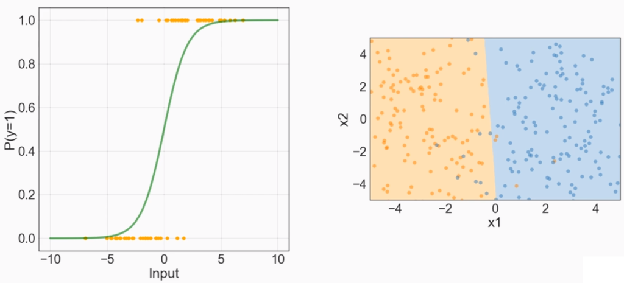

```python
from IPython.display import Image
from IPython.core.display import HTML
Image('ds_8.png')
```

Logistic Regression Curve and Classification

The blue dots on the lef side are errors and those yellow dots on the blue background are also erros. Missclassified (False Positives).

False positive: Not actually the intended objects or values but classified or detected as the intended object.

False Negatives: intended values or objects but estimated or classified or detected as non-intended.

Linear Regression is affected by outliers

```python
x=df1.drop('wine_type',axis=1)
y=df1['wine_type']
```

```python
from sklearn.linear_model import LogisticRegression
```

```python
#Instantiation
clf=LogisticRegression()
clf
```

```
LogisticRegression(C=1.0, class_weight=None, dual=False, fit_intercept=True,
                   intercept_scaling=1, l1_ratio=None, max_iter=100,
                   multi_class='warn', n_jobs=None, penalty='l2',
                   random_state=None, solver='warn', tol=0.0001, verbose=0,
                   warm_start=False)
```

```python
# fit the model
import warnings
warnings.filterwarnings('ignore')# ignores warnings
clf.fit(x,y)
```

```
LogisticRegression(C=1.0, class_weight=None, dual=False, fit_intercept=True,
                   intercept_scaling=1, l1_ratio=None, max_iter=100,
                   multi_class='warn', n_jobs=None, penalty='l2',
                   random_state=None, solver='warn', tol=0.0001, verbose=0,
                   warm_start=False)
```

```python
pred=clf.predict(x)
```

```python
acc=metrics.accuracy_score(y,pred)
acc
```

```
0.9719101123595506
```

```python
# Putting all together
#Import package
import warnings
warnings.filterwarnings('ignore')# ignores warnings
from sklearn.linear_model import LogisticRegression

# Load target or required datasets
x=df1.drop('wine_type',axis=1)
y=df1['wine_type']

# Instantiate model
clf=LogisticRegression()

# Fit model
clf.fit(x,y)

# Do prediction
pred=clf.predict(x)

# Compute the accuracy
acc=metrics.accuracy_score(y,pred)
print(f"The accuracy obtained is {acc}")
```

```
The accuracy obtained is 0.9719101123595506
```

```python
# For data like that of LR, a sinfle column (accuracy drops)
#Import package
import warnings
warnings.filterwarnings('ignore')# ignores warnings
from sklearn.linear_model import LogisticRegression

# Load target or required datasets
x=df1.drop('wine_type',axis=1)
x=df1[['proline']]
y=df1['wine_type']

# Instantiate model
clf=LogisticRegression()

# Fit model
clf.fit(x,y)

# Do prediction
pred=clf.predict(x)

# Compute the accuracy
acc=metrics.accuracy_score(y,pred)
print(f"The accuracy obtained is {acc}")
```

```
The accuracy obtained is 0.6853932584269663
```

### 7.3: K-Nearest Neighbors

Classifier points based on distance to closest k number of points

Learning is done by similarity, meaning the most similiar points which are closest to the point of interest determine its class (voting)

Not good with high dimensional data. The curse of dimensionality!

Categorical features are usually not good to deal with

Normalizing the data usually will increase accuracy. Otherwise variables with larger values will dominate the distance metric. Use the right normalization methods like

\begin{align} \frac{x-\mu}{\sigma} \ or \ \frac{X-X_{min}}{X_{max}-X_{min}}\\ \end{align}

Very large dataset can be extremely slow. However, algorithms have been developed to optimize the process.

Example: Classify the blackpoint:

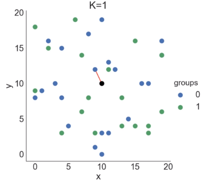

```python
from IPython.display import Image
from IPython.core.display import HTML
Image('ds_9.png')
# K increases 1,2,3,...n
```

```python
df3=df1
```

```python
# One column of dataset only
```

```python
from sklearn.neighbors import KNeighborsClassifier
```

```python
# Instantiate the classifier (clf)
clf=KNeighborsClassifier()
clf
```

```
KNeighborsClassifier(algorithm='auto', leaf_size=30, metric='minkowski',
                     metric_params=None, n_jobs=None, n_neighbors=5, p=2,
                     weights='uniform')
```

```python
x=df3[['proline']]
y=df3['wine_type']
```

```python
clf.fit(x,y)
```

```
KNeighborsClassifier(algorithm='auto', leaf_size=30, metric='minkowski',
                     metric_params=None, n_jobs=None, n_neighbors=5, p=2,
                     weights='uniform')
```

```python
pred=clf.predict(x)
```

```python
acc=metrics.accuracy_score(y, pred)
acc
```

```
0.7696629213483146
```

```python
# Putting all together

# Packages
from sklearn.neighbors import KNeighborsClassifier
from sklearn import metrics

# Instantiate the classifier (clf)
clf=KNeighborsClassifier()

# Select dataset of interest for training and fitting
x=df3[['proline']]
y=df3['wine_type']

# Fitting the model
clf.fit(x,y)

# Perform prediction
pred=clf.predict(x)

# Compute the accuracy of prediction
acc=metrics.accuracy_score(y, pred)
print(f"The accuracy of the KNeighborclassifier is {acc}")
```

```
The accuracy of the KNeighborclassifier is 0.7696629213483146
```

```python
# Multi-column dataset only: Use all columns
```

```python
# Dataset containing all columns
x=df3.drop('wine_type',axis=1)
y=df3['wine_type']
```

```python
# Fitting
clf.fit(x,y)
```

```
KNeighborsClassifier(algorithm='auto', leaf_size=30, metric='minkowski',
                     metric_params=None, n_jobs=None, n_neighbors=5, p=2,
                     weights='uniform')
```

```python
# Predict
pred=clf.predict(x)
```

```python
metrics.accuracy_score(y, pred) # about 2% increase
```

```
0.7865168539325843
```

```python
# Putting all together
# Multicolumn: Improves the accuracy by 2%

# Packages
from sklearn.neighbors import KNeighborsClassifier
from sklearn import metrics

# Instantiate the classifier (clf)
clf=KNeighborsClassifier()

# Select dataset of interest for training and fitting
# Dataset containing all columns
x=df3.drop('wine_type',axis=1)
y=df3['wine_type']

# Fitting the model
clf.fit(x,y)

# Perform prediction
pred=clf.predict(x)

# Compute the accuracy of prediction
acc=metrics.accuracy_score(y, pred)
print(f"The accuracy of the KNeighborclassifier is {acc}")
```

```
The accuracy of the KNeighborclassifier is 0.7865168539325843
```

Remark: scales are different and the accuracy is poor!

```python
# Perform preproccessing
from sklearn.preprocessing import StandardScaler
```

```python
#Instantiate
prep=StandardScaler()
prep
```

```
StandardScaler(copy=True, with_mean=True, with_std=True)
```

```python
# Standardize or tranform data
x=prep.fit_transform(x)
```

```python
# Fit model
clf.fit(x,y)
pred=clf.predict(x)
```

```python
# Accuracy --> a huge jump in accuracy by about 19%
metrics.accuracy_score(y,pred)
```

```
0.9775280898876404
```

```python
# Putting all together
# Scaling the data points to improve the accuracy

# Packages
from sklearn.neighbors import KNeighborsClassifier
from sklearn import metrics
# Perform preproccessing
from sklearn.preprocessing import StandardScaler

# Instantiate the classifier (clf)
clf=KNeighborsClassifier()

#Instantiate
prep=StandardScaler()

# Select dataset of interest for training and fitting
# Dataset containing all columns
x=df3.drop('wine_type',axis=1)
y=df3['wine_type']

# Standardize or tranform data
x=prep.fit_transform(x)

# Fitting the model
clf.fit(x,y)

# Perform prediction
pred=clf.predict(x)

# Compute the accuracy of prediction
acc=metrics.accuracy_score(y, pred)
print(f"The accuracy of the KNeighborclassifier is {acc*100}%")
```

```
The accuracy of the KNeighborclassifier is 97.75280898876404%
```

### 7.4: Decision Trees

For example, when guessing a country name one starts with questions like:

```
is it in Northern Hemisphere?
is it in Europe?
is its GDP larger than X amount
```

Works like a human mind, and is easy to represent and interpret

Is a non-linear model

Graph like structure where nodes represent decisions to split on, and leaves represent the outcome.

The feature to split on is selected based on Information gain or Entropy

The basic principle is to reduce impurity or to increase information gain as much as possible.

Results in lower variance in the branches after splitting, meaning more points from the same class leads to lower entropy values (less impurity).

The first feature to split on is the most import one that results in largest decrease in impurity.

$$Entropy=-\sum_{i=0}^n (p_{i}) log_{2}(p_{i})$$

Information Gain = Entropy Parent - Weighted Average of Entropy CHildren

Goal: Maximize Information Gain

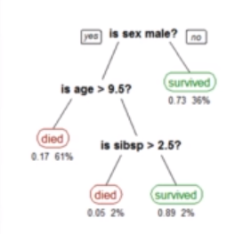

```python
from IPython.display import Image
from IPython.core.display import HTML
Image('ds_10.png')
```

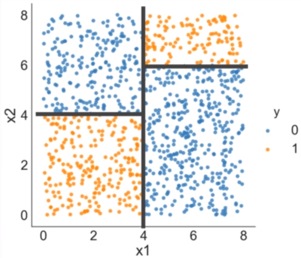

```python
# Classification based on Decision Tree
from IPython.display import Image
from IPython.core.display import HTML
Image('ds_11.png')
```

```python
# Tree Coding

# Import the required packages
#Import decision tree classifier/estimator
from sklearn.tree import DecisionTreeClassifier
```

```python
# Instantiate the classifier/estimator
tree=DecisionTreeClassifier()
```

```python
# Select datasets X, and Y --> single colum in this case
x=df3[['proline']]
y=df3['wine_type']
```

```python
# Fit the classifier/estimator
tree.fit(x,y)
```

```
DecisionTreeClassifier(class_weight=None, criterion='gini', max_depth=None,
                       max_features=None, max_leaf_nodes=None,
                       min_impurity_decrease=0.0, min_impurity_split=None,
                       min_samples_leaf=1, min_samples_split=2,
                       min_weight_fraction_leaf=0.0, presort=False,
                       random_state=None, splitter='best')
```

```python
# Prediction
pred=tree.predict(x)
```

```python
# Compute accuracy
acc=metrics.accuracy_score(y,pred)
acc
```

```
0.8876404494382022
```

```python
# Putting all together
# Tree Coding

# Import the required packages
#Import decision tree classifier/estimator
from sklearn.tree import DecisionTreeClassifier

# Instantiate the classifier/estimator
tree=DecisionTreeClassifier()

# Select datasets X, and Y --> single colum in this case
x=df3[['proline']]
y=df3['wine_type']

# Fit the classifier/estimator
tree.fit(x,y)

# Prediction
pred=tree.predict(x)

# Compute accuracy
acc=metrics.accuracy_score(y,pred)
print(f"The accuracy of the decision tree model is {round(acc*100,2)}%")
```

```
The accuracy of the decision tree model is 88.76%
```

```python
# Let us see how the accuracy changes when all features are employed
# Select datasets X, and Y --> All features of X are used
x=df3.drop('wine_type', axis=1)
y=df3['wine_type']
```

```python
# Fit the classifier/estimator
tree.fit(x,y)
```

```
DecisionTreeClassifier(class_weight=None, criterion='gini', max_depth=None,
                       max_features=None, max_leaf_nodes=None,
                       min_impurity_decrease=0.0, min_impurity_split=None,
                       min_samples_leaf=1, min_samples_split=2,
                       min_weight_fraction_leaf=0.0, presort=False,
                       random_state=None, splitter='best')
```

```python
# Prediction
pred=tree.predict(x)
```

```python
# Compute accuracy
acc=metrics.accuracy_score(y,pred)
print(f"The accuracy of the decision tree model is {round(acc*100,2)}%")
```

```
The accuracy of the decision tree model is 100.0%
```

```python
# Putting all together
# Tree Coding: all features are employed

# Import the required packages
#Import decision tree classifier/estimator
from sklearn.tree import DecisionTreeClassifier

# Instantiate the classifier/estimator
tree=DecisionTreeClassifier()

# Select datasets X, and Y --> All features of X are used
x=df3.drop('wine_type', axis=1)
y=df3['wine_type']

# Fit the classifier/estimator
tree.fit(x,y)

# Prediction
pred=tree.predict(x)

# Compute accuracy
acc=metrics.accuracy_score(y,pred)
print(f"The accuracy of the decision tree model is {round(acc*100,2)}%")
```

```
The accuracy of the decision tree model is 100.0%
```

NB: The accuracy is 100% due to overfitting! That is, the same dataset is used for both training and testing!

### 7.5: Random Forest

Many decision trees coming together (put together) make up a forest

Is an ensemble learning technique

Ensemble methods use multiple learning algorithms which will yield better predictive performance than the ones constituting the ensemble.

Usually ever 1 or 2 level deep trees are enough for a random forest to perform much better than a single deep decision tree.

A subset of bootstrapped data, and subset of features are used in each tree

sqrt (total # of features) number of features are selected randomly.

The final decision depends on the majority vote

Helps decrease the high variance that results from using a single tree

More robust and generalizable compared to decision trees

The variables that are used by many trees will hint their importance

Bootstrapping is random selection with replacement. The same row and the same columns can be selected multiple times.

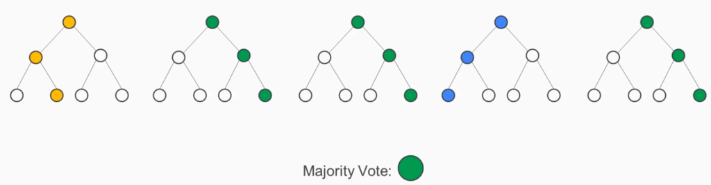

```python
# Classification based on Random Forest (set of Decision Trees)
from IPython.display import Image
from IPython.core.display import HTML
Image('ds_12.png')
```

```python
# Coding Random Forest

# Import Packages
from sklearn.ensemble import RandomForestClassifier
```

```python
df3.head()
```

|  | alcohol | malic_acid | ash | alcalinity_of_ash | magnesium | total_phenols | flavanoids | nonflavanoid_phenols | proanthocyanins | color_intensity | hue | od280/od315_of_diluted_wines | proline | wine_type |
| --- | --- | --- | --- | --- | --- | --- | --- | --- | --- | --- | --- | --- | --- | --- |
| 0 | 14.23 | 1.71 | 2.43 | 15.6 | 127.0 | 2.80 | 3.06 | 0.28 | 2.29 | 5.64 | 1.04 | 3.92 | 1065.0 | 0 |
| 1 | 13.20 | 1.78 | 2.14 | 11.2 | 100.0 | 2.65 | 2.76 | 0.26 | 1.28 | 4.38 | 1.05 | 3.40 | 1050.0 | 0 |
| 2 | 13.16 | 2.36 | 2.67 | 18.6 | 101.0 | 2.80 | 3.24 | 0.30 | 2.81 | 5.68 | 1.03 | 3.17 | 1185.0 | 0 |
| 3 | 14.37 | 1.95 | 2.50 | 16.8 | 113.0 | 3.85 | 3.49 | 0.24 | 2.18 | 7.80 | 0.86 | 3.45 | 1480.0 | 0 |
| 4 | 13.24 | 2.59 | 2.87 | 21.0 | 118.0 | 2.80 | 2.69 | 0.39 | 1.82 | 4.32 | 1.04 | 2.93 | 735.0 | 0 |

```python
x=df3[['proline']] #Single Input
y=df3['wine_type']
```

```python
clf=RandomForestClassifier()
clf
```

```
RandomForestClassifier(bootstrap=True, class_weight=None, criterion='gini',
                       max_depth=None, max_features='auto', max_leaf_nodes=None,
                       min_impurity_decrease=0.0, min_impurity_split=None,
                       min_samples_leaf=1, min_samples_split=2,
                       min_weight_fraction_leaf=0.0, n_estimators='warn',
                       n_jobs=None, oob_score=False, random_state=None,
                       verbose=0, warm_start=False)
```

```python
clf.fit(x,y)
```

```
RandomForestClassifier(bootstrap=True, class_weight=None, criterion='gini',
                       max_depth=None, max_features='auto', max_leaf_nodes=None,
                       min_impurity_decrease=0.0, min_impurity_split=None,
                       min_samples_leaf=1, min_samples_split=2,
                       min_weight_fraction_leaf=0.0, n_estimators=10,
                       n_jobs=None, oob_score=False, random_state=None,
                       verbose=0, warm_start=False)
```

```python
pred=clf.predict(x)
```

```python
metrics.accuracy_score(y,pred)
```

```
0.8707865168539326
```

```python
# Putting all together
# Random Forest Coding: Single Data feature is employed

# Import the required packages
#Import decision tree classifier/estimator
from sklearn.ensemble import RandomForestClassifier

# Instantiate the classifier/estimator
clf=RandomForestClassifier()

# Select datasets X, and Y --> Single feature
x=df3[['proline']] #Single Input
y=df3['wine_type']

# Fit the classifier/estimator
clf.fit(x,y)

# Prediction
pred=clf.predict(x)

# Compute accuracy
acc=metrics.accuracy_score(y,pred)
print(f"The accuracy of the Random Forest model is {round(acc*100,2)}%")
```

```
The accuracy of the Random Forest model is 87.64%
```

```python
# Using all features
x=df3.drop('wine_type', axis=1)
y=df3['wine_type']
```

```python
clf.fit(x,y)
```

```
RandomForestClassifier(bootstrap=True, class_weight=None, criterion='gini',
                       max_depth=None, max_features='auto', max_leaf_nodes=None,
                       min_impurity_decrease=0.0, min_impurity_split=None,
                       min_samples_leaf=1, min_samples_split=2,
                       min_weight_fraction_leaf=0.0, n_estimators=10,
                       n_jobs=None, oob_score=False, random_state=None,
                       verbose=0, warm_start=False)
```

```python
pred=clf.predict(x)
```

```python
metrics.accuracy_score(y,pred)
```

```
1.0
```

```python
# Putting all together
# Random Forest Coding: All available Data feature are employed

# Import the required packages
#Import decision tree classifier/estimator
from sklearn.ensemble import RandomForestClassifier

# Instantiate the classifier/estimator
clf=RandomForestClassifier()

# Select datasets X, and Y --> All feature
x=df3.drop('wine_type', axis=1)
y=df3['wine_type']

# Fit the classifier/estimator
clf.fit(x,y)

# Prediction
pred=clf.predict(x)

# Compute the classification accuracy: Y_true vas Y_pred
acc=metrics.accuracy_score(y,pred)
print(f"The accuracy of the Random Forest model is {round(acc*100,2)}%")
```

```
The accuracy of the Random Forest model is 100.0%
```

The result (100% accuracy is not realistic)! It is only due to overfitting! Training and testing datasets are the same!

### 7.6: K-Means Clustering

K-means clustering

No labels are used - unsupervised learning

The basic principle is to cluster the points to the nearest centroid

There are K number of centroids (mean of the clusters)

The algorithm is very similar to K-means neigbors, however that one is supervised and instance based learning - meaning all the points in training data were used to classify, whereas the K-means only uses the K centroids to cluster the points.

Observations are clustered into k groups, where each observation is assigned to the group with the nearest mean.

Need to decide on K

The created clusters can be used as a feature for other algorithms

Used in market segmentation, image segmentation and more

Not friendly with non-numerical data

Good when groups are distinct and linearly separable

Not good when too much overlapping, too much noise or outliers

The created K-clusters can be used as features for other algorithms

As depicted in the figure below, three centroids/means are provided and the distance of each point to the means is computed and is clustered to the closest centroid.

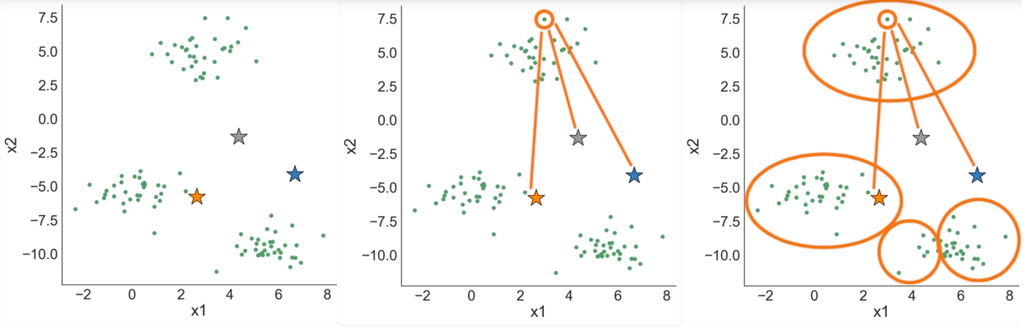

```python
# CLustering based on K_means/Centroids
from IPython.display import Image
from IPython.core.display import HTML
Image('ds_13.png')
```

First iteration: (1) Assign points to the initial centroids (2) Recalculate the centroid mean and move the centroid to the new location

As iteration increases, the points are clustered to the group/cluster they belong. The number of outliers or false positives decreases. See the figure the below.

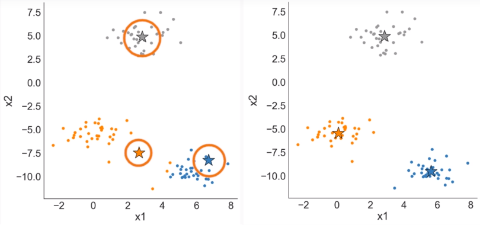

```python
# CLustering based on K_means/Centroids -- iterations
from IPython.display import Image
from IPython.core.display import HTML
Image('ds_14.png')
```

```python
# K-means coding

# Import the required package
from sklearn.cluster import KMeans
```

```python
# Instantiate the KMeans
clu=KMeans(n_clusters=3)
clu
```

```
KMeans(algorithm='auto', copy_x=True, init='k-means++', max_iter=300,
       n_clusters=3, n_init=10, n_jobs=None, precompute_distances='auto',
       random_state=None, tol=0.0001, verbose=0)
```

```python
# Fit the model
clu.fit(x)
```

```
KMeans(algorithm='auto', copy_x=True, init='k-means++', max_iter=300,
       n_clusters=3, n_init=10, n_jobs=None, precompute_distances='auto',
       random_state=None, tol=0.0001, verbose=0)
```

```python
# Prediction
pred=clu.predict(x)
pred
```

```
array([1, 1, 1, 1, 0, 1, 1, 1, 1, 1, 1, 1, 1, 1, 1, 1, 1, 1, 1, 0, 0, 0,
       1, 1, 0, 0, 1, 1, 0, 1, 1, 1, 1, 1, 1, 0, 0, 1, 1, 0, 0, 1, 1, 0,
       0, 1, 1, 1, 1, 1, 1, 1, 1, 1, 1, 1, 1, 1, 1, 2, 0, 2, 0, 2, 2, 0,
       2, 2, 0, 0, 0, 2, 2, 1, 0, 2, 2, 2, 0, 2, 2, 0, 0, 2, 2, 2, 2, 2,
       0, 0, 2, 2, 2, 2, 2, 0, 0, 2, 0, 2, 0, 2, 2, 2, 0, 2, 2, 2, 2, 0,
       2, 2, 0, 2, 2, 2, 2, 2, 2, 2, 0, 2, 2, 2, 2, 2, 2, 2, 2, 2, 0, 2,
       2, 0, 0, 0, 0, 2, 2, 2, 0, 0, 2, 2, 0, 0, 2, 0, 0, 2, 2, 2, 2, 0,
       0, 0, 2, 0, 0, 0, 2, 0, 2, 0, 0, 2, 0, 0, 0, 0, 2, 2, 0, 0, 0, 0,
       0, 2])
```

```python
# Clustering accuracy
# We dunno y and we can't do comparison between y and pred
# It can be an input to another algorithm
x['pred']=pred
```